# Fishing effort indicators - for SC17 2021

Details regarding the fishery effort data extraction, formatting, and summarization for the Ecosystem and Climate Indicators Report Card presented to SC17. This work is intended to be ongoing, and therefore ensuring consistency and transparency for repeatability was paramount. In addition, we are hoping that this report card will be a living document. These details are provided to encourage discussion and engagement in an effort to craft indicators that are informative and valuable for the members.

## Load R packages

```r
library(tidyverse)
library(magrittr)
library(maps)
library(zoo)
library(RODBC)
library(sp)
library(RGeostats)
```

## Data Extraction

This section described the data extraction command for the in-house databases (S_BEST and L_BEST) at SPC, and is for internal transparency for future iterations of this ecosystem and climate indicators report card.

```r
###################################################################################
# Metrics of purse seine and longline effort
  # Temporal: Annual metrics & 5 year rolling average
  # Metrics:
    # 1. central tendency and inertia (All PS, LL; FAD sets; free-school sets)
    # 2. distributional spread (All PS, LL; FAD sets; free-school sets)
###################################################################################

db1 <- "driver=SQL Server;server=nouSQL03;database=LOG_MASTER"
channel <- odbcDriverConnect(db1)

## S_BEST purse seine catch and effort
s_eff_query <- "
SELECT      s.S_BEST_ID, YY, MM, lat_short, lon_short, ez_aprx_code, days,
            sh.Schass_code, days_sch, sets_sch
FROM        best.S_BEST_AGG s
LEFT OUTER JOIN  best.S_BEST_AGG_SCHEFF sh on s.S_BEST_ID = sh.S_BEST_ID
WHERE       s.GEAR_CODE like 'S' and YY>1999 and YY<2020
"
s_eff <- sqlQuery(channel, s_eff_query, as.is=TRUE)

s_catch_query <- "
SELECT      s.S_BEST_ID, YY, MM, lat_short, lon_short, ez_aprx_code, days,
            Schass_code, sp_code, sp_mt
FROM        best.S_BEST_AGG s
LEFT OUTER JOIN  best.S_BEST_AGG_CATCH c on s.S_BEST_ID = c.S_BEST_ID
WHERE       s.GEAR_CODE like 'S' and YY>1999 and YY<2020
"
s_catch <- sqlQuery(channel, s_catch_query, as.is=TRUE)


## L_BEST longline catch and effort
l_eff_query <- "
SELECT      L_BEST_ID, YY, MM, lat_short, lon_short, hhooks, std_effort
FROM        best.L_BEST_AGG
WHERE       GEAR_CODE like 'L' and YY>1999 and YY<2020
"
l_eff <- sqlQuery(channel, l_eff_query, as.is=TRUE)

l_catch_query <- "
SELECT      l.L_BEST_ID, YY, MM, lat_short, lon_short, sp_code, sp_n, sp_mt
FROM        best.L_BEST_AGG l
LEFT OUTER JOIN  best.L_BEST_AGG_CATCH c on l.L_BEST_ID = c.L_BEST_ID
WHERE       l.GEAR_CODE like 'L' and YY>1999 and YY<2020
"
l_catch <- sqlQuery(channel, l_catch_query, as.is=TRUE)

# Close the database connection
odbcCloseAll()
```

## Spatial domain

Filter data to include only information from the WCPFC.

```r
########################################################
# Read in WCPO boundary info
########################################################
wcp_ca = read.csv("wcpfc_ca_stat_area.csv")
# Convert to spatial polygon
wcp = Polygon(wcp_ca)
wcp = SpatialPolygons(list(Polygons(list(wcp), ID = "CA")),
                      proj4string=CRS("+proj=longlat +ellps=WGS84 +datum=WGS84 +no_defs"))

# Check that points are in WCP-CA
coords = wcp@polygons[[1]]@Polygons[[1]]@coords
```

## Data manipulation and formatting

```r
# Format data and filter out observations outside WCPFC-CA
s_eff %<>% mutate(lat = as.numeric(substr(lat_short,1,2)), lat.dir = substr(lat_short,3,3),
                  lon = as.numeric(substr(lon_short,1,3)), lon.dir = substr(lon_short,4,4),
                  lat = ifelse(lat.dir=='S', lat*-1,lat), lon = ifelse(lon.dir=='W', 360-lon, lon)) %>%
  select(-c(lon_short, lon.dir, lat_short, lat.dir)) %>%
  mutate(days_sch = as.numeric(days_sch), sets_sch = as.numeric(sets_sch))

s_catch %<>% mutate(lat = as.numeric(substr(lat_short,1,2)), lat.dir = substr(lat_short,3,3),
                  lon = as.numeric(substr(lon_short,1,3)), lon.dir = substr(lon_short,4,4),
                  lat = ifelse(lat.dir=='S', lat*-1,lat), lon = ifelse(lon.dir=='W', 360-lon, lon)) %>%
  select(-c(lon_short, lon.dir, lat_short, lat.dir))

l_eff %<>% mutate(lat = as.numeric(substr(lat_short,1,2)), lat.dir = substr(lat_short,3,3),
                  lon = as.numeric(substr(lon_short,1,3)), lon.dir = substr(lon_short,4,4),
                  lat = ifelse(lat.dir=='S', lat*-1,lat), lon = ifelse(lon.dir=='W', 360-lon, lon)) %>%
  select(-c(lon_short, lon.dir, lat_short, lat.dir)) %>%
  mutate(hhoks = as.numeric(hhooks), std_effort = as.numeric(std_effort))

l_catch %<>% mutate(lat = as.numeric(substr(lat_short,1,2)), lat.dir = substr(lat_short,3,3),
                  lon = as.numeric(substr(lon_short,1,3)), lon.dir = substr(lon_short,4,4),
                  lat = ifelse(lat.dir=='S', lat*-1,lat), lon = ifelse(lon.dir=='W', 360-lon, lon)) %>%
  select(-c(lon_short, lon.dir, lat_short, lat.dir))


s_eff$WCP_CA = point.in.polygon(s_eff$lon, s_eff$lat, coords[,1], coords[,2])
  s_eff %<>% filter(WCP_CA %in% c(1,2)) %>%  select(-WCP_CA)

# School association codes
ASS <- c(4,3) # drifting FAD only
AFAD = c(5) # anchored FAD
ASSWH = c(6,7) # whale and whale shark sets
UNA <- c(1,2) # free school


# Aggregate all set types together
s_eff_all = s_eff %>% filter(Schass_code %in% c(1,2,3,4,5,6,7)) %>% group_by(YY,MM, lat, lon) %>%
            mutate(sets_sch = ifelse(sets_sch<0,0,sets_sch)) %>%
            summarise(days = sum(days_sch), sets = sum(sets_sch) ) %>% ungroup()


s_eff_fad = s_eff %>% filter(Schass_code %in% ASS) %>%
            mutate(sets_sch = ifelse(sets_sch<0,0,sets_sch)) %>%
            group_by(YY,MM, lat, lon) %>%
            summarise(days = sum(days_sch), sets = sum(sets_sch) ) %>% ungroup()
s_eff_free = s_eff %>%  filter(Schass_code %in% UNA) %>%
            mutate(sets_sch = ifelse(sets_sch<0,0,sets_sch)) %>%
            group_by(YY,MM, lat, lon) %>%
            summarise(days = sum(days_sch), sets = sum(sets_sch) ) %>% ungroup()


s_catch$WCP_CA = point.in.polygon(s_catch$lon, s_catch$lat, coords[,1], coords[,2])
  s_catch %<>% filter(WCP_CA %in% c(1,2)) %>%  select(-WCP_CA)

l_eff$WCP_CA = point.in.polygon(l_eff$lon, l_eff$lat, coords[,1], coords[,2])
  l_eff %<>% filter(WCP_CA %in% c(1,2)) %>%  select(-WCP_CA)
  l_eff %<>% mutate(hhooks = as.numeric(hhooks))

  l_catch$WCP_CA = point.in.polygon(l_catch$lon, l_catch$lat, coords[,1], coords[,2])
  l_catch %<>% filter(WCP_CA %in% c(1,2)) %>%  select(-WCP_CA)
```

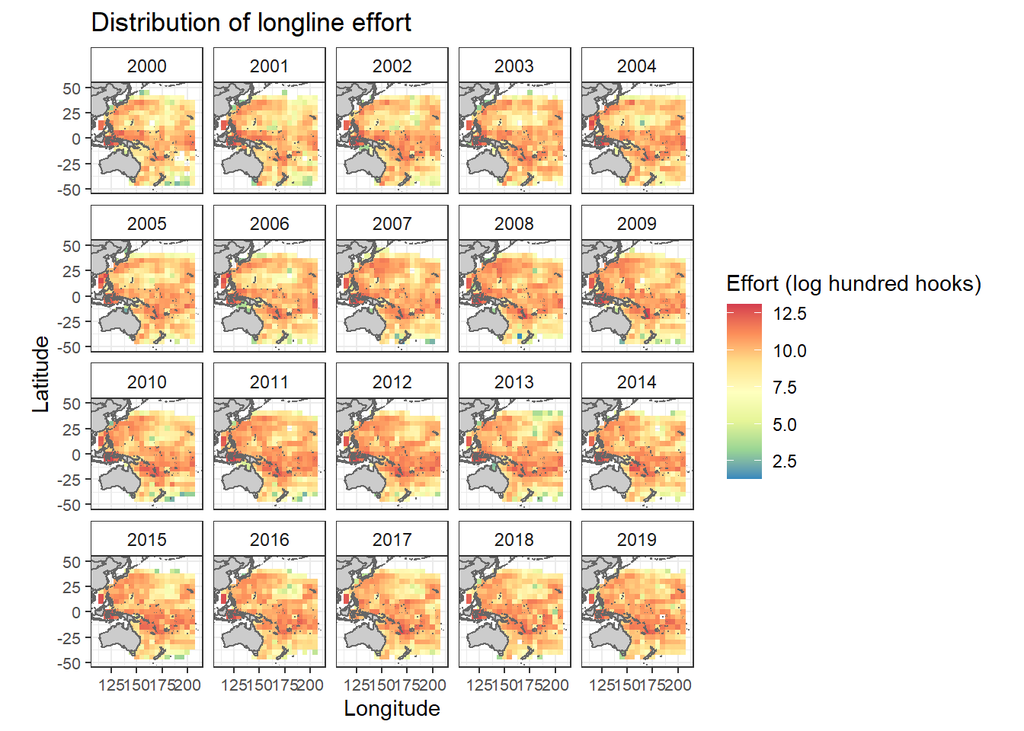

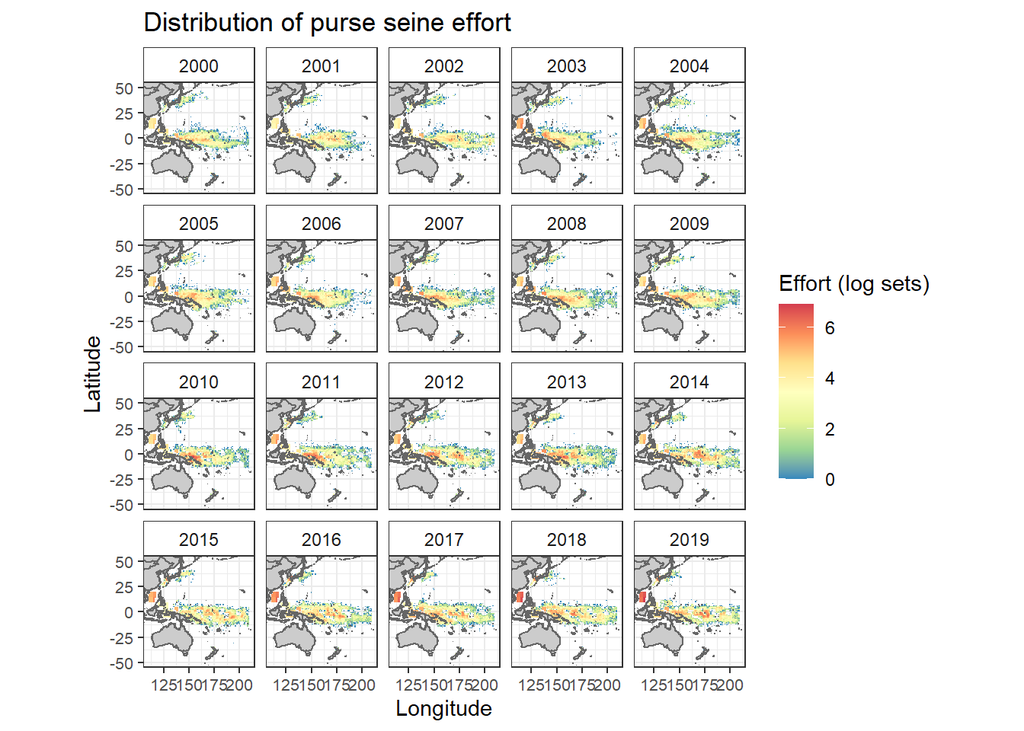

## Centre of gravity and inertia

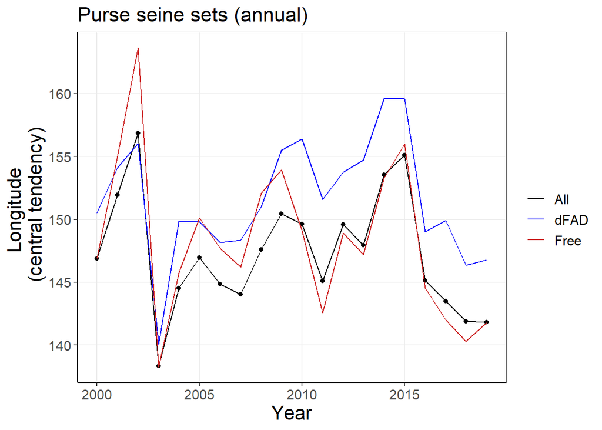

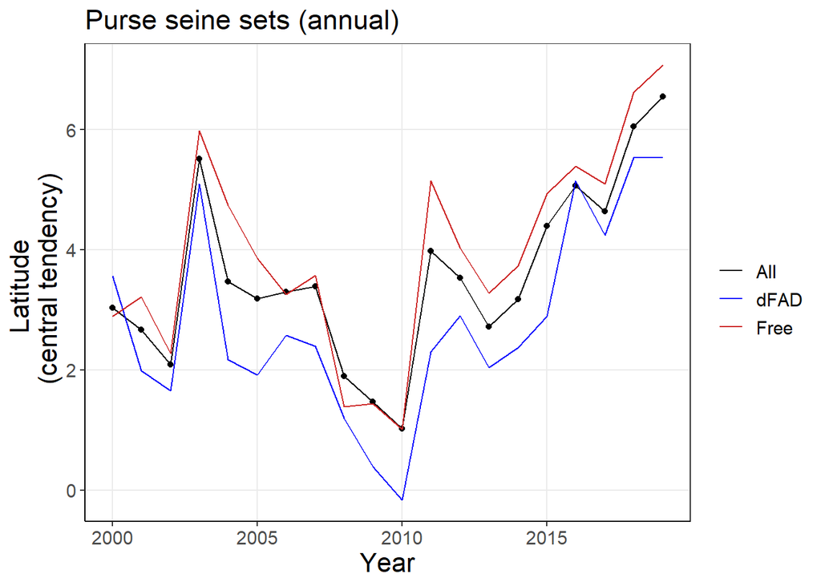

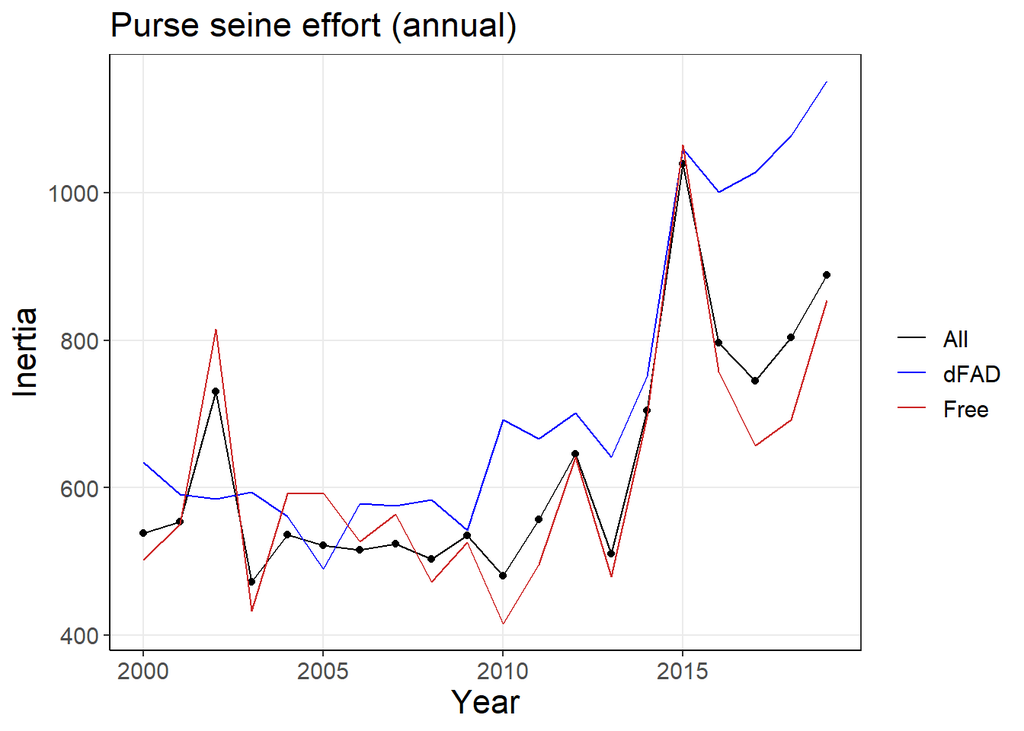

```r
####################################################################################
# Calculate centre of gravity and inertia - annual
####################################################################################

# Calculate annual values
ann.cg.inert = function(dat, effort, lab){
cgi = c()

for(i in 1:length(unique(dat$YY))){
    CG = dat %>% filter(YY==unique(YY)[i]) %>% select(lon,lat,effort,YY)
    names(CG)[3] = 'effort'
    CG %<>%  group_by(lon,lat) %>% summarize(z=sum(as.numeric(effort),na.rm=T))
    db = db.create(x1=CG$lon, x2=CG$lat, z1=CG$z)
    projec.define(projection="mean",db=db)

    projec.toggle(0)
    CG = SI.cgi(db, flag.plot=F)
    cgi  = rbind(cgi, c("yy"=unique(dat$YY)[i], "CG"=CG$center, "inertia"=CG$inertia, "iso"=CG$iso))
}
cgi %<>% data.frame() %>% rename(lon=CG1, lat=CG2)
return(cgi)
}

ps.cg = ann.cg.inert(s_eff_all, effort='sets', lab='ps_annual')
fad.cg = ann.cg.inert(s_eff_fad, effort='sets', lab='fad_annual')
free.cg = ann.cg.inert(s_eff_free, effort='sets', lab='free_annual')
```

Calculate centre of gravity on a seasonal basis (year-quarter).

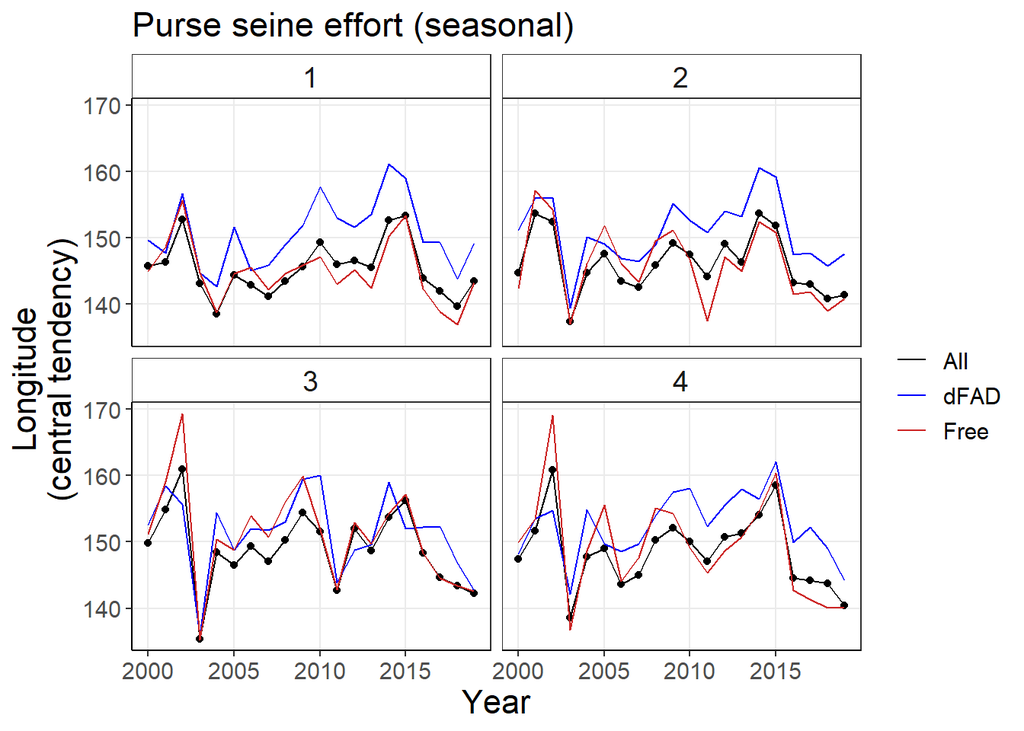

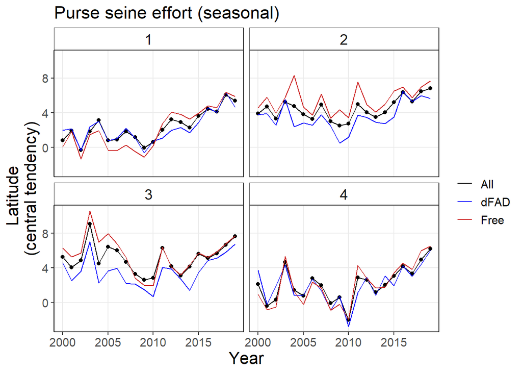

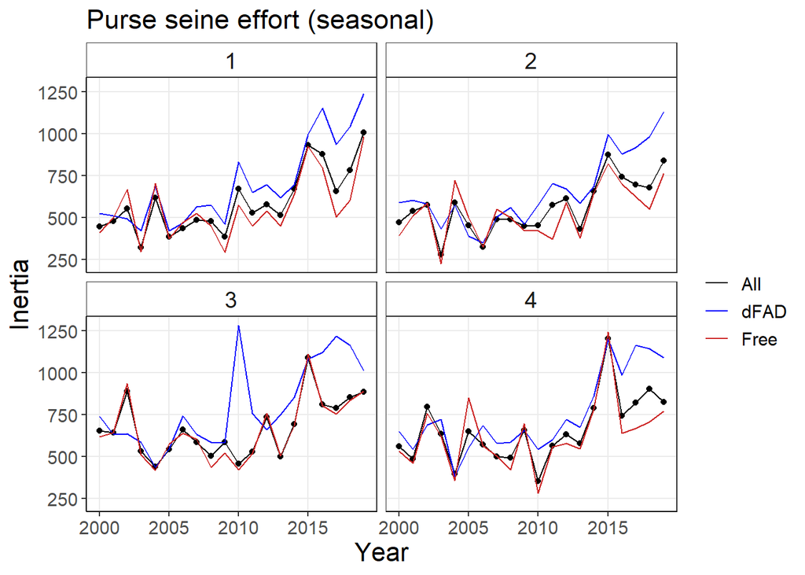

```r
# Calculate seasonal centre of gravity and inertia
seas.cg.inert = function(dat, effort){
cgi = c()

for(i in 1:length(unique(dat$YY))){
  for(s in unique(dat$qtr)){
    CG = dat %>% filter(YY==unique(YY)[i], qtr==s) %>% select(lon,lat,effort,YY, qtr)
    names(CG)[3] = 'effort'
    CG = db.create(x1=CG$lon, x2=CG$lat, z1=CG$effort)
    projec.toggle(0)
    CG = SI.cgi(CG, flag.plot=F)
    cgi  = rbind(cgi, c("yy"=unique(dat$YY)[i], "qtr" = s, "CG"=CG$center,
                        "inertia"=CG$inertia, "iso"=CG$iso))
  }
}
cgi %<>% data.frame() %>% rename(lon=CG1, lat=CG2)
return(cgi)
}

ps.seas.cg = seas.cg.inert(s_eff_all %>% mutate(qtr = ceiling(MM/3)), effort='sets')
fad.seas.cg = seas.cg.inert(s_eff_fad %>% mutate(qtr = ceiling(MM/3)), effort='sets')
free.seas.cg = seas.cg.inert(s_eff_free %>% mutate(qtr = ceiling(MM/3)), effort='sets')
```

Calculate centre of gravity on a 5-year rolling average.

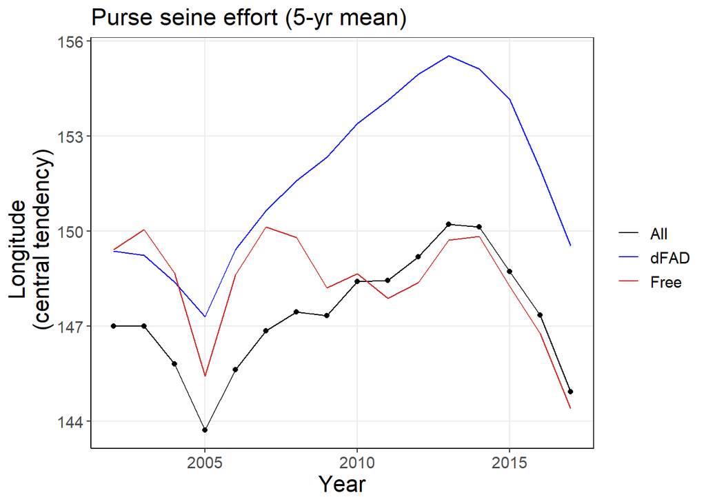

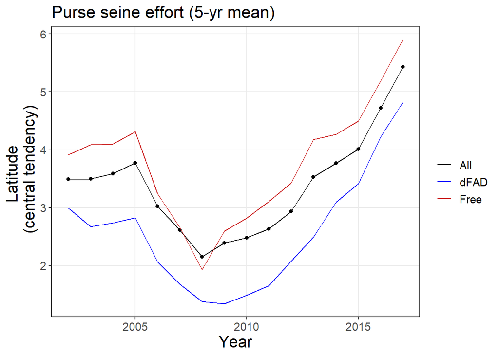

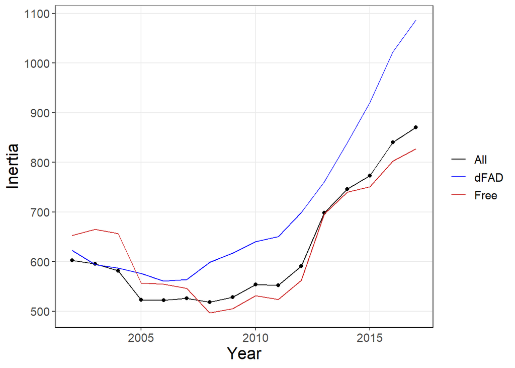

```r
###########################################################
# 5-yr rolling average - with mid-point year as reference
###########################################################

roll5.cg.inert = function(dat, effort){
  cgi = c()

  for(i in 1:(length(unique(dat$YY))-4)){
    CG = dat %>% filter(YY %in% c(unique(YY)[c(i:(i+4))])) %>% select(lon,lat,effort,YY)
    names(CG)[3] = 'effort'
   CG = db.create(x1=CG$lon, x2=CG$lat, z1=CG$effort)
   projec.toggle(0)
   CG = SI.cgi(CG, flag.plot=F)

    cgi  = rbind(cgi, c("yy"=unique(dat$YY)[i+2], "CG"=CG$center, "inertia"=CG$inertia, "iso"=CG$iso))
  }

  cgi %<>% data.frame() %>% rename(lon=CG1, lat=CG2)
  return(cgi)
}

ps.cg5 = roll5.cg.inert(s_eff_all, effort='sets')
fad.cg5 = roll5.cg.inert(s_eff_fad, effort='sets')
free.cg5 = roll5.cg.inert(s_eff_free, effort='sets')
```

Centre of gravity calculated as a 5-year rolling average, seasonally.

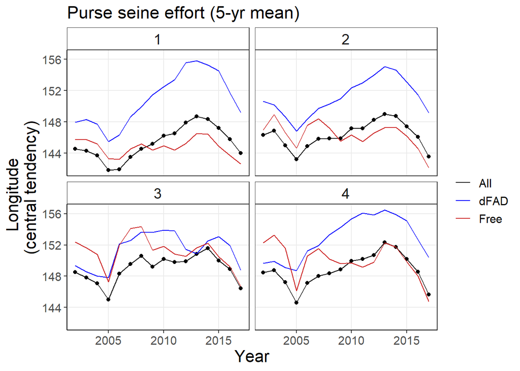

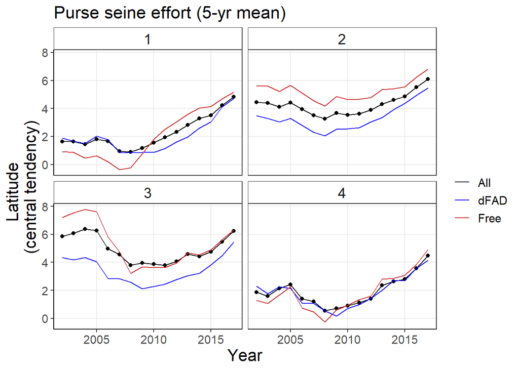

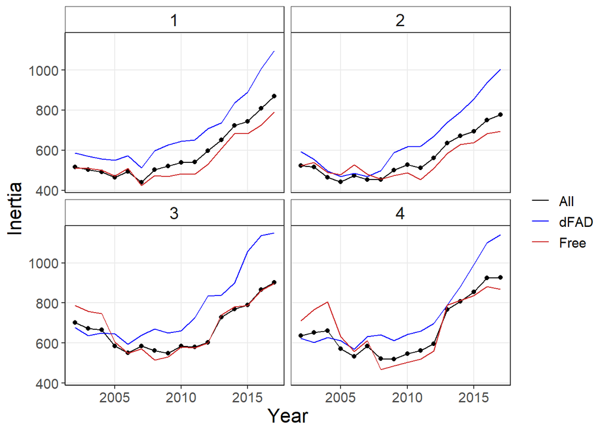

```r
roll5.seas.cg.inert = function(dat, effort){
  cgi = c()

  for(i in 1:(length(unique(dat$YY))-4)){
    for(s in unique(dat$qtr)){
    CG = dat %>% filter(YY %in% c(unique(YY)[c(i:(i+4))]), qtr==s) %>% select(lon,lat,effort,YY, qtr)
    names(CG)[3] = 'effort'
    CG = db.create(x1=CG$lon, x2=CG$lat, z1=CG$effort)
    projec.toggle(0)
    CG = SI.cgi(CG, flag.plot=F)
    cgi  = rbind(cgi, c("yy"=unique(dat$YY)[i+2],'qtr'=s, "CG"=CG$center,
                        "inertia"=CG$inertia, "iso"=CG$iso))
    }
  }

  cgi %<>% data.frame() %>% rename(lon=CG1, lat=CG2)
  return(cgi)
}


ps.seas.cg5 = roll5.seas.cg.inert(s_eff_all %>%  mutate(qtr = ceiling(MM/3)), effort='sets')
fad.seas.cg5 = roll5.seas.cg.inert(s_eff_fad %>%  mutate(qtr = ceiling(MM/3)), effort='sets')
free.seas.cg5 = roll5.seas.cg.inert(s_eff_free %>%  mutate(qtr = ceiling(MM/3)), effort='sets')
```

## Area occupied

Here we calculate the area occupied by each of the fisheries, on an annual basis.

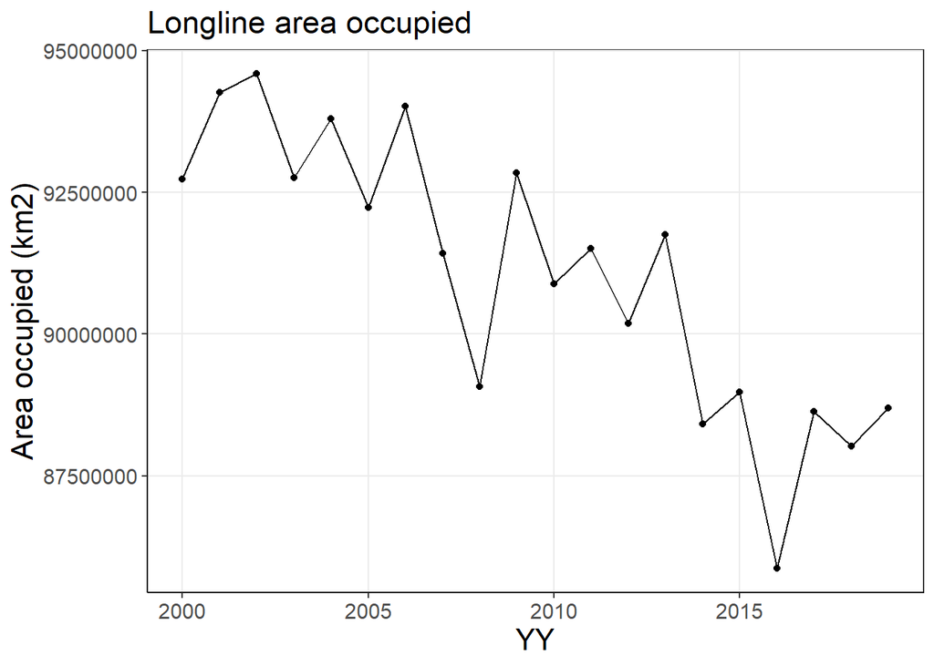

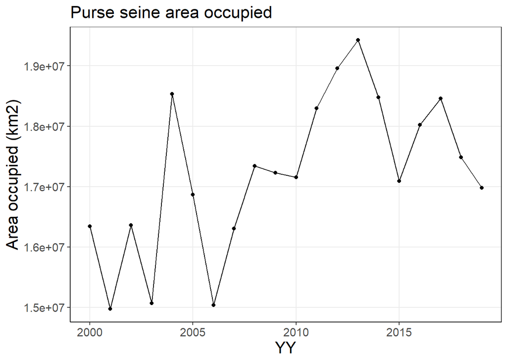

```r
####################################################################
# Area occupied - unique 1x1 cells fished
####################################################################

area.occ = function(dat, effort, res){
    library(raster)
    # get area of each cell
    grid.df <- expand.grid('Lat'=seq(min(dat$lat),max(dat$lat),res),
                           'Lon'=seq(min(dat$lon),max(dat$lon),res))
    r <- raster(ext = extent(min(dat$lon), max(dat$lon)+res, min(dat$lat),
                             max(dat$lat)+res), res=c(res,res))
    grid.df$Area_km2 =  area(r)@data@values
    detach('package:raster')

    ao = dat %>% filter(effort>0) %>%
          left_join(grid.df %>%  rename(lat=Lat, lon=Lon)) %>%
          mutate(cell = paste(lon, lat, sep=':')) %>%
          select(YY, cell, Area_km2) %>% distinct() %>%
          group_by(YY) %>%
          summarise(cells = n_distinct(cell), area = sum(Area_km2)) %>%
          mutate(cells5 = rollapply(cells,5,mean, align='center',fill=NA),
                 area5 = rollapply(area,5,mean, align='center',fill=NA))
    return(ao)

}

ll.ao = area.occ(l_eff, effort='hhooks', res=5) # res = spatial resolution 5x5
ps.ao = area.occ(s_eff_all, effort='sets', res=1) # spatial resolution of 1x1
```